# Homework

## Exercise 7.10 Model Selection

By replacing the $Log\sim Log$ model `J4` with a cubic polynomial one, the procedure goes like this:

```r
library(DAAG); attach(ironslag)
n <- length(magnetic)
e1 <- e2 <- e3 <- e4 <- numeric(n)

# the four models
L1 <- lm(magnetic ~ chemical)
L2 <- lm(magnetic ~ chemical + I(chemical^2))
L3 <- lm(log(magnetic) ~ chemical)
L4 <- lm(magnetic ~ chemical + I(chemical^2) + I(chemical^3))

# for n-fold cross validation
# fit models on leave-one-out samples
for (k in 1:n){
  y <- magnetic[-k]
  x <- chemical[-k]
  ## linear
  J1 <- lm(y ~ x)
  yhat1 <- J1$coef[1] + J1$coef[2]*chemical[k]
  e1[k] <- magnetic[k] - yhat1
  ## quadratic
  J2 <- lm(y ~ x + I(x^2))
  yhat2 <- J2$coef[1] + J2$coef[2]*chemical[k] +
    J2$coef[3]*chemical[k]^2
  e2[k] <- magnetic[k] - yhat2
  ## log linear
  J3 <- lm(log(y) ~ x)
  logyhat3 <- J3$coef[1] + J3$coef[2]*chemical[k]
  yhat3 <- exp(logyhat3)
  e3[k] <- magnetic[k] - yhat3
  ## cubic
  J4 <- lm(y ~ x + I(x^2) + I(x^3))
  yhat4 <- J4$coef[1] + J4$coef[2]*chemical[k] +
    J4$coef[3]*chemical[k]^2 + J4$coef[4]*chemical[k]^3
  e4[k] <- magnetic[k] - yhat4
}
detach(ironslag)
```

```r
# MSE
c(mean(e1^2), mean(e2^2), mean(e3^2), mean(e4^2))
```

```
## [1] 19.55644 17.85248 18.44188 18.17756
```

According to the prediction error criterion, the quadratic model `L2` should be chosen as the best fit for the data.

```r
# adjusted R squared
summary(L1)$adj.r.squared
```

```
## [1] 0.5281545
```

```r
summary(L2)$adj.r.squared
```

```
## [1] 0.5768151
```

```r
summary(L3)$adj.r.squared
```

```
## [1] 0.5280556
```

```r
summary(L4)$adj.r.squared
```

```
## [1] 0.5740396
```

Under the adjusted-$R^2$ criterion, still, `L2` is considered to be the best fit for the data.

## Exercise 8.1 two-sample Cram´er-von Mises for univariate data

First we implement the algorithm:

```r
cramer_von_Mises.stat <- function(x, y){
  n = length(x); m = length(y)
  Fn = ecdf(x); Gm = ecdf(y)
  z = c(x, y)
  n*m*mean((Fn(z) - Gm(z))^2)/(n + m)
}

perm.test <- function(x, y, R = 999, test_stat){
  z <- c(x, y) # pooled sample
  N = length(z)
  n = length(x); m = N - n
  K <- 1:N # indices for the pooled sample
  W <- numeric(R) # storage for replicates

  for (i in 1:R){
    #generate indices k for the first sample
    k <- sample(K, size = n)
    x1 = z[k]; y1 = z[-k]
    W[i] <- test_stat(x1, y1)
  }
  W0 <- test_stat(x, y)
  p <- mean(c(W0, W) >= W0)
  return(list(W0 = W0, W.perm = W, p.value = p))
}
```

Now we try our algorithm on data used in examples 8.1 and 8.2:

```r
attach(chickwts)
x <- sort(as.vector(weight[feed == "soybean"]))
y <- sort(as.vector(weight[feed == "linseed"]))
detach(chickwts)

res <- perm.test(x, y, 999, cramer_von_Mises.stat)

res$p.value
```

```
## [1] 0.411
```

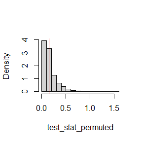

```r
hist(res$W.perm, freq = FALSE, xlab = "test_stat_permuted",
     main = NULL)
abline(v = res$W0, col = "red")
```

The result shows that the distributions of x and y are to much extent alike, thus we prefer the null hypothesis.

# Exercise 8.2 Spearman rank correlation test

```r
data(scor, package = "bootstrap")
x = scor[, 3]; y = scor[, 4]
z <- c(x, y)

cor_bv <- function(z, ix){
  stopifnot(length(z) %% 2 == 0)
  n = length(z)/2
  z <- z[ix]
  cor(z[1:n], z[-(1:n)], method = "spearman")
}

library(boot)
boot.obj <- boot(z, statistic = cor_bv,
                 sim = "permutation", R = 999)

boot.obj$t0 ## original correlation
```

```
## [1] 0.7419719
```

```r
tb <- c(boot.obj$t, boot.obj$t0)
p.value <- mean(tb >= boot.obj$t0)
p.value
```

```
## [1] 0.001
```

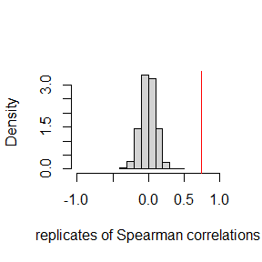

```r
hist(boot.obj$t, freq = FALSE, main = "", xlim = c(-1, 1),
     xlab = "replicates of Spearman correlations")
abline(v = boot.obj$t0, col = "red")
```

Compare with `cor.test`:

```r
options(warn = -1)
cor.test(x, y, method = "spearman")
```

```
##
##  Spearman's rank correlation rho
##
## data:  x and y
## S = 29303, p-value < 2.2e-16
## alternative hypothesis: true rho is not equal to 0
## sample estimates:
##       rho
## 0.7419719
```

They are consistent.

## Exercise 9.3 Random Walk Metropolis

The goal is to generate a standard Cauchy Markov chain.

Set the proposal distribution $g(Y|X_t)=\mathrm{N}(X_t,1)$:

```r
## random walk Metropolis
mcmc.rw <- function(N = 5000, x0, f=dcauchy, sigma = 1){
  x <- numeric(N)
  x[1] = x0
  u <- runif(N)
  for (i in 2:N) {
    xt <- x[i-1]
    y <- rnorm(1, sd = sigma) + xt
    num = f(y)
    den = f(xt)
    if (u[i] <= num/den) x[i] <- y
    else x[i] <- xt
  }
  return(x)
}
```

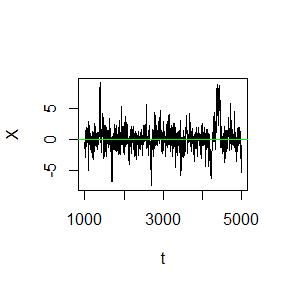

```r
N <- 5000
b <- 1000

x = mcmc.rw(N, x0 = rcauchy(1), f = dcauchy)
x = x[(b + 1):N]

plot((b + 1):N, y = x, type = "l", main = "", xlab = "t", ylab = "X")
abline(h = 0, col = "green")
```

```r
quantile(x, c(0.25, 0.75))
```

```
##        25%        75%
## -0.7467715  0.9010549
```

```r
qcauchy(p = c(0.25, 0.75))
```

```
## [1] -1  1
```

Sometimes they are close and sometimes not, it depends.

## Exercise 9.8 Gibbs Sampler

Under the condition that $a, b, n$ are fixed, we have

$$X|Y\sim \text{Binomial}(n,y),~~Y|X\sim\text{Beta}(x+a,n-x+b),$$

where $x=0,1,\dots,n$, $0\le y\le1$.

Use Gibbs sampler to generate a chain that has joint density $f(x, y)$.

```r
Gibbs <- function(N = 5000, x0 = c(0, 0),
                  a = 1, b = 1, n = 100) {
  X <- matrix(0, N, 2) # the chain, a bivariate sample
  X[1, ] = x0          # initialize

  for (i in 2:N){
    y <- X[i-1, 2]
    X[i, 1] <- rbinom(1, n, y)
    x <- X[i-1, 1]
    X[i, 2] <- rbeta(1, x + a, n - x + b)
  }
  return(X)
}
```

```r
N <- 5000            # the length of chain
burn <- 1000         # the burn-in length

####set parameters####
a <- b <- 1
n = 100

X <- Gibbs(N, c(0,0), a, b, n)
X <- X[(burn + 1):N, ]
```

## Gelman-Rubin Method

We generate $m$ chains, and we use $\psi_{ij}$ to denote the statistic $\psi(X^{(i)}_{1},\dots, X^{(i)}_{j})$ for the $i-th$ chain.

#### exercise 9.3

Choose mean as the diagnostic statistics $\psi$.

```r
Gelman.Rubin <- function(psi) {
  # psi[i,j] is the statistic psi(X[i,1:j]) for chain in i-th row of X
  psi <- as.matrix(psi)
  n <- ncol(psi)
  m <- nrow(psi)
  psi.means <- rowMeans(psi)     #row means
  B <- n * var(psi.means)        #between variance est.
  psi.w <- apply(psi, 1, "var")  #within variances
  W <- mean(psi.w)               #within est.
  v.hat <- W*(n-1)/n + (B/n)     #upper variance est.
  r.hat <- v.hat / W             #G-R statistic
  return(r.hat)
}
```

```r
m = 4
N = 25000
burn = 1000

X <- array(dim = c(m, N))

#choose overdispersed initial values
x0 = c(-10, -5, 5, 10)

####generating chains####
for (i in 1:m){
  X[i, ] <- mcmc.rw(N, x0[i])
}
```

```r
#compute diagnostic statistics
psi <- t(apply(X, 1, cumsum))
for (i in 1:nrow(psi))
  psi[i, ] <- psi[i, ] / (1:ncol(psi))
print(Gelman.Rubin(psi))
```

```
## [1] 1.398301
```

Plot $\psi$ for $4$ chains:

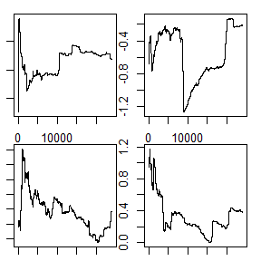

```r
par(mfrow = c(2, 2), mar = c(1, 1, 1, 1))
for (i in 1:m){
  plot(psi[i, (burn + 1):N], type = "l",
       xlab = i, ylab = bquote(psi))
}
```

Plot the sequence of $\hat{R}$ statistics:

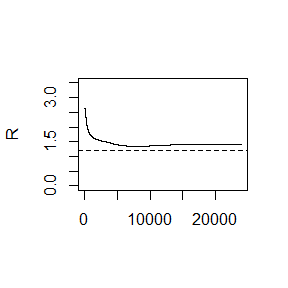

```r
par(mfrow = c(1, 1))
R.hat <- rep(0, N)
for (j in (burn + 1):N){
  R.hat[j] <- Gelman.Rubin(psi[, 1:j])
}
plot(R.hat[(burn + 1):N], type = "l", ylim = c(0, 3.5),
     xlab = "", ylab = "R")
abline(h = 1.2, lty = 2)
```

Target distribution is Cauchy, whose variance is infinity, and proposal distribution is normal distribution, with $\sigma=1$. This has caused a slow convergence, as it can be seen from the figure above.

#### Exercise 9.8

The original article by Gelman & Rubin, as well as the Bayesian Data Analysis textbook of Gelman et al., recommends calculating the **potential scale reduction factor (PSRF)** *separately* for each scalar parameter of interest. To deduce convergence, it is then required that all PSRFs are close to 1.

Still we choose mean as the diagnostic statistics $\psi$.

```r
m = 4
N = 25000
burn = 1000

X <- array(0, dim = c(m, N, 2))

#choose overdispersed initial values
x0 = matrix(c(0,  25, 50,  75,
              0, .25, .5, .75), 4, 2)

a <- b <- 1
n = 100

####generating chains####
for (i in 1:m){
  X[i, , ] <- Gibbs(N, x0[i, ])
}
```

```r
#compute diagnostic statistics for Xt and Yt respectively
psi.x <- t(apply(X[, , 1], 1, cumsum))
for (i in 1:nrow(psi.x))
  psi.x[i, ] <- psi.x[i, ] / (1:ncol(psi.x))
print(Gelman.Rubin(psi.x))
```

```
## [1] 1.60149
```

```r
psi.y <- t(apply(X[, , 2], 1, cumsum))
for (i in 1:nrow(psi.y))
  psi.y[i, ] <- psi.y[i, ] / (1:ncol(psi.y))
print(Gelman.Rubin(psi.y))
```

```
## [1] 1.595275
```

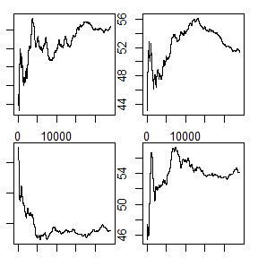

```r
par(mfrow = c(2, 2), mar = c(1, 1, 1, 1))
for (i in 1:m){
  plot(psi.x[i, (burn + 1):N], type = "l",
       xlab = i, ylab = "psi.x")
}
```

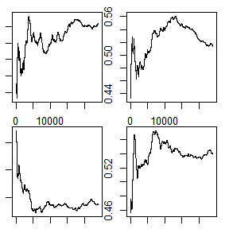

```r
par(mfrow = c(2, 2), mar = c(1, 1, 1, 1))
for (i in 1:m){
  plot(psi.y[i, (burn + 1):N], type = "l",
       xlab = i, ylab = "psi.y")
}
```

Plot the sequence of $\hat{R}$ statistics for $X_t$ and $Y_t$ separately:

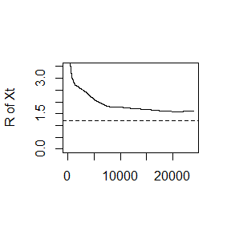

```r
par(mfrow = c(1, 1))
R.hat.x <- rep(0, N)
for (j in (burn + 1):N){
  R.hat.x[j] <- Gelman.Rubin(psi.x[, 1:j])
}
plot(R.hat.x[(burn + 1):N], type = "l", ylim = c(0, 3.5),
     xlab = "", ylab = "R of Xt")
abline(h = 1.2, lty = 2)
```

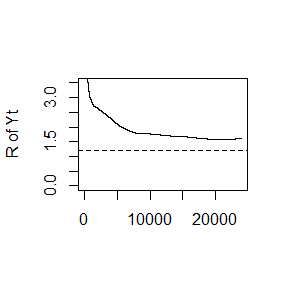

```r
par(mfrow = c(1, 1))
R.hat.y <- rep(0, N)
for (j in (burn + 1):N){
  R.hat.y[j] <- Gelman.Rubin(psi.y[, 1:j])
}
plot(R.hat.y[(burn + 1):N], type = "l", ylim = c(0, 3.5),
     xlab = "", ylab = "R of Yt")
abline(h = 1.2, lty = 2)
```

## Exercise 11.3

Write a function to compute

$$\sum_{k = 0}^{\infty}\frac{(-1)^k}{k!2^k}\frac{\|a\|^{2k + 2}}{(2k +
1)(2k + 2)}\frac{\Gamma(\frac{d+1}{2})\Gamma(k+\frac32)}{\Gamma(k +
\frac{d}{2} + 1)}.$$

#### $k$-th coefficient

While computing, use exponential to avoid producing `NaN`s:

```r
fk <- function(k, a, d){
  stopifnot(d >= 1 && length(a) == d)
  A = log(sum(a^2))

  signk = (k %% 2 == 0)

  signk*exp((k + 1)*A + lgamma((d + 1)/2) + lgamma(k + 3/2) - lgamma(k + d/2 + 1) - lgamma(k + 1) - k*log(2))/(2*k + 1)/(2*k + 2)
}

fk(20, rep(1, 10), 10)
```

```
## [1] 8.513396e-12
```

#### Sum

Use vectors instead of loops to compute the sum:

```r
Sk <- function(k, a, d){
  stopifnot(d >= 1 && length(a) == d)
  A = log(sum(a^2))

  K = 0:k
  signk = rep(c(1, -1), (k + 2) %/% 2)
  signk = signk[1:(k + 1)]
  sum(signk*exp((K + 1)*A + lgamma(d/2 + 1/2) + lgamma(K + 3/2) -
                  lgamma(K + d/2 + 1) - lgamma(K + 1) - K*log(2))/(2*K + 1)/(2*K + 2))
}

Sk(20, rep(1, 10), 10)
```

```
## [1] 1.633613
```

```r
Sk(20, rep(1, 10), 10) - Sk(19, rep(1, 10), 10)
```

```
## [1] 8.513412e-12
```

#### Evaluation

When $a=c(1,2)^T$,

```r
a = c(1, 2); d = 2
K = 0:15
S <- rep(0, length(K))

for (k in K){
  S[k + 1] <- Sk(k, a, d)
}

data = data.frame(k = K, sum = S)

knitr::kable(data, align = c("c", "c"))
```

| k | sum |
| --- | --- |
| 0 | 1.963495 |
| 1 | 1.349903 |
| 2 | 1.605567 |
| 3 | 1.505698 |
| 4 | 1.540652 |
| 5 | 1.529729 |
| 6 | 1.532794 |
| 7 | 1.532016 |
| 8 | 1.532196 |
| 9 | 1.532158 |
| 10 | 1.532165 |
| 11 | 1.532164 |
| 12 | 1.532164 |
| 13 | 1.532164 |
| 14 | 1.532164 |
| 15 | 1.532164 |

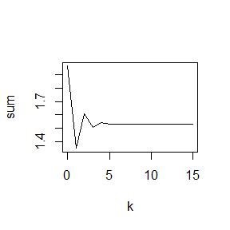

```r
plot(data, type = "l")
```

## Exercise 11.5

Write a function to solve the equation

$$\begin{align}
\frac{2\Gamma(\frac k
2)}{\sqrt{\pi(k-1)}\Gamma(\frac{k-1}2)}\int_{0}^{c_{k-1}}(1+\frac{u^2}{k-1})^{-k/2}\mathrm{d}u\\
=\frac{2\Gamma(\frac {k+1}2)}{\sqrt{\pi k}\Gamma(\frac
k2)}\int_0^{c_k}(1+\frac{u^2}k)^{-(k+ 1)/2}\mathrm d u,
\end{align}$$

for $a$, where $k\in \mathbb{N}^*$ and

$$c_k = \sqrt{\frac{a^2k}{k + 1-a^2}}.$$

Obviously the equation is in the form of

$$f_{k-1}(a)=f_{k}(a)$$

where

$$f_k(a) = \frac{2\Gamma(\frac {k+1}2)}{\sqrt{\pi k}\Gamma(\frac
k2)}\int_0^{c_k}(1+\frac{u^2}k)^{-(k+ 1)/2}\mathrm d u = \mathrm{Pr}(|
t(k) |\le c_k) = 1-2S_k(a),$$

where $t(k)$ is a random variable from Student t distribution with degree of freedom $k$. Thus the solution to the equation here is exactly the intersection point $A(k)$ of curves $S_{k-1}(a)$ and $S_k(a)$ in exercise 11.4.

Write a function to compute $f_k(a)$:

```r
f <- function(k, a){
  stopifnot(k + 1 - a^2 > 0)
  ck = sqrt(a^2*k/(k+1-a^2))

  b = 2/sqrt(pi*k)*exp(lgamma((k+1)/2)-lgamma(k/2))

  integrand <- function(u){
    (1 + u^2/k)^{-(k+1)/2}
  }

  I = integrate(integrand, 0, ck)

  b*I$value
}
```

```r
K = c(4:25, 100, 500, 1000)
ans = rep(0, length(K))
eps <- .Machine$double.eps^{0.25}

for (i in 1:length(K)){
  k = K[i]
  ans[i] <- uniroot(function(a){
    f(k - 1, a) - f(k, a)
  }, interval = c(1, 1.9))$root

}

data = data.frame(k = K, a = ans)
knitr::kable(data, align = c("c", "c"))
```

| k | a |
| --- | --- |
| 4 | 1.492098 |
| 5 | 1.533551 |
| 6 | 1.562745 |
| 7 | 1.584438 |
| 8 | 1.601155 |
| 9 | 1.614517 |
| 10 | 1.625383 |
| 11 | 1.634409 |
| 12 | 1.642026 |
| 13 | 1.648540 |
| 14 | 1.654175 |
| 15 | 1.659097 |
| 16 | 1.663434 |
| 17 | 1.667284 |
| 18 | 1.670725 |
| 19 | 1.673818 |
| 20 | 1.676615 |
| 21 | 1.679155 |
| 22 | 1.681472 |
| 23 | 1.683595 |
| 24 | 1.685547 |
| 25 | 1.687348 |
| 100 | 1.720601 |
| 500 | 1.729747 |
| 1000 | 1.730898 |